# startup 2

### startup success predictor

##### Startup Success Prediction Using Machine Learning

This project aims to predict whether a startup will be successful (Acquired) or unsuccessful (Closed) using machine learning techniques. Historical startup data containing funding information, milestones, investor participation, location details, and business characteristics is used to build predictive models.

##### Import Libraries

In this step, we import all necessary Python libraries for data analysis, visualization, preprocessing, machine learning model development, and performance evaluation. These libraries help us manipulate data, create visualizations, build models, and measure model performance.

```python
import pandas as pd
import numpy as np

import matplotlib.pyplot as plt
import seaborn as sns

import warnings
warnings.filterwarnings('ignore')

from sklearn.model_selection import train_test_split
from sklearn.preprocessing import LabelEncoder
from sklearn.impute import SimpleImputer

from sklearn.linear_model import LogisticRegression
from sklearn.tree import DecisionTreeClassifier
from sklearn.ensemble import RandomForestClassifier

from sklearn.metrics import (
    accuracy_score,
    classification_report,
    confusion_matrix,
    roc_auc_score,
    roc_curve
)
```

##### Load Dataset

The startup dataset is loaded into a Pandas DataFrame. This dataset contains information about startup funding, milestones, investor involvement, geographical details, and startup status, which will be used for analysis and prediction.

```python
df = pd.read_csv(r"C:\Users\lenovo\Downloads\startup.csv",index_col=0,header=0)
df
```

| startup_code | state_code | latitude | longitude | zip_code | id | city | address | name | labels | founded_at | ... | object_id | has_VC | has_angel | has_roundA | has_roundB | has_roundC | has_roundD | avg_participants | is_top500 | status |
| --- | --- | --- | --- | --- | --- | --- | --- | --- | --- | --- | --- | --- | --- | --- | --- | --- | --- | --- | --- | --- | --- |
| 1005 | CA | 42.358880 | -71.056820 | 92101 | c:6669 | San Diego | NaN | Bandsintown | 1 | 1/1/2007 | ... | c:6669 | 0 | 1 | 0 | 0 | 0 | 0 | 1.0000 | 0 | acquired |
| 204 | CA | 37.238916 | -121.973718 | 95032 | c:16283 | Los Gatos | NaN | TriCipher | 1 | 1/1/2000 | ... | c:16283 | 1 | 0 | 0 | 1 | 1 | 1 | 4.7500 | 1 | acquired |
| 1001 | CA | 32.901049 | -117.192656 | 92121 | c:65620 | San Diego | San Diego CA 92121 | Plixi | 1 | 3/18/2009 | ... | c:65620 | 0 | 0 | 1 | 0 | 0 | 0 | 4.0000 | 1 | acquired |
| 738 | CA | 37.320309 | -122.050040 | 95014 | c:42668 | Cupertino | Cupertino CA 95014 | Solidcore Systems | 1 | 1/1/2002 | ... | c:42668 | 0 | 0 | 0 | 1 | 1 | 1 | 3.3333 | 1 | acquired |
| 1002 | CA | 37.779281 | -122.419236 | 94105 | c:65806 | San Francisco | San Francisco CA 94105 | Inhale Digital | 0 | 8/1/2010 | ... | c:65806 | 1 | 1 | 0 | 0 | 0 | 0 | 1.0000 | 1 | closed |
| ... | ... | ... | ... | ... | ... | ... | ... | ... | ... | ... | ... | ... | ... | ... | ... | ... | ... | ... | ... | ... | ... |
| 352 | CA | 37.740594 | -122.376471 | 94107 | c:21343 | San Francisco | NaN | CoTweet | 1 | 1/1/2009 | ... | c:21343 | 0 | 0 | 1 | 0 | 0 | 0 | 6.0000 | 1 | acquired |
| 721 | MA | 42.504817 | -71.195611 | 1803 | c:41747 | Burlington | Burlington MA 1803 | Reef Point Systems | 0 | 1/1/1998 | ... | c:41747 | 1 | 0 | 0 | 1 | 0 | 0 | 2.6667 | 1 | closed |
| 557 | CA | 37.408261 | -122.015920 | 94089 | c:31549 | Sunnyvale | NaN | Paracor Medical | 0 | 1/1/1999 | ... | c:31549 | 0 | 0 | 0 | 0 | 0 | 1 | 8.0000 | 1 | closed |
| 589 | CA | 37.556732 | -122.288378 | 94404 | c:33198 | San Francisco | NaN | Causata | 1 | 1/1/2009 | ... | c:33198 | 0 | 0 | 1 | 1 | 0 | 0 | 1.0000 | 1 | acquired |
| 462 | CA | 37.386778 | -121.966277 | 95054 | c:26702 | Santa Clara | Santa Clara CA 95054 | Asempra Technologies | 1 | 1/1/2003 | ... | c:26702 | 0 | 0 | 0 | 1 | 0 | 0 | 3.0000 | 1 | acquired |

923 rows × 48 columns

```python
df.shape
```

```
(923, 48)
```

```python
df.head()
```

| startup_code | state_code | latitude | longitude | zip_code | id | city | address | name | labels | founded_at | ... | object_id | has_VC | has_angel | has_roundA | has_roundB | has_roundC | has_roundD | avg_participants | is_top500 | status |
| --- | --- | --- | --- | --- | --- | --- | --- | --- | --- | --- | --- | --- | --- | --- | --- | --- | --- | --- | --- | --- | --- |
| 1005 | CA | 42.358880 | -71.056820 | 92101 | c:6669 | San Diego | NaN | Bandsintown | 1 | 1/1/2007 | ... | c:6669 | 0 | 1 | 0 | 0 | 0 | 0 | 1.0000 | 0 | acquired |
| 204 | CA | 37.238916 | -121.973718 | 95032 | c:16283 | Los Gatos | NaN | TriCipher | 1 | 1/1/2000 | ... | c:16283 | 1 | 0 | 0 | 1 | 1 | 1 | 4.7500 | 1 | acquired |
| 1001 | CA | 32.901049 | -117.192656 | 92121 | c:65620 | San Diego | San Diego CA 92121 | Plixi | 1 | 3/18/2009 | ... | c:65620 | 0 | 0 | 1 | 0 | 0 | 0 | 4.0000 | 1 | acquired |
| 738 | CA | 37.320309 | -122.050040 | 95014 | c:42668 | Cupertino | Cupertino CA 95014 | Solidcore Systems | 1 | 1/1/2002 | ... | c:42668 | 0 | 0 | 0 | 1 | 1 | 1 | 3.3333 | 1 | acquired |
| 1002 | CA | 37.779281 | -122.419236 | 94105 | c:65806 | San Francisco | San Francisco CA 94105 | Inhale Digital | 0 | 8/1/2010 | ... | c:65806 | 1 | 1 | 0 | 0 | 0 | 0 | 1.0000 | 1 | closed |

5 rows × 48 columns

```python
df.info()
```

```
<class 'pandas.core.frame.DataFrame'>
Index: 923 entries, 1005 to 462
Data columns (total 48 columns):
 #   Column                    Non-Null Count  Dtype
---  ------                    --------------  -----
 0   state_code                923 non-null    object
 1   latitude                  923 non-null    float64
 2   longitude                 923 non-null    float64
 3   zip_code                  923 non-null    object
 4   id                        923 non-null    object
 5   city                      923 non-null    object
 6   address                   430 non-null    object
 7   name                      923 non-null    object
 8   labels                    923 non-null    int64
 9   founded_at                923 non-null    object
```

[output cut: 40 more lines]

```python
df.describe()
```

|  | latitude | longitude | labels | age_first_funding_year | age_last_funding_year | age_first_milestone_year | age_last_milestone_year | relationships | funding_rounds | funding_total_usd | ... | is_consulting | is_othercategory | has_VC | has_angel | has_roundA | has_roundB | has_roundC | has_roundD | avg_participants | is_top500 |
| --- | --- | --- | --- | --- | --- | --- | --- | --- | --- | --- | --- | --- | --- | --- | --- | --- | --- | --- | --- | --- | --- |
| count | 923.000000 | 923.000000 | 923.000000 | 923.000000 | 923.000000 | 771.000000 | 771.000000 | 923.000000 | 923.000000 | 9.230000e+02 | ... | 923.000000 | 923.000000 | 923.000000 | 923.000000 | 923.000000 | 923.000000 | 923.000000 | 923.000000 | 923.000000 | 923.000000 |
| mean | 38.517442 | -103.539212 | 0.646804 | 2.235630 | 3.931456 | 3.055353 | 4.754423 | 7.710726 | 2.310943 | 2.541975e+07 | ... | 0.003250 | 0.322860 | 0.326111 | 0.254605 | 0.508126 | 0.392199 | 0.232936 | 0.099675 | 2.838586 | 0.809317 |
| std | 3.741497 | 22.394167 | 0.478222 | 2.510449 | 2.967910 | 2.977057 | 3.212107 | 7.265776 | 1.390922 | 1.896344e+08 | ... | 0.056949 | 0.467823 | 0.469042 | 0.435875 | 0.500205 | 0.488505 | 0.422931 | 0.299729 | 1.874601 | 0.393052 |
| min | 25.752358 | -122.756956 | 0.000000 | -9.046600 | -9.046600 | -14.169900 | -7.005500 | 0.000000 | 1.000000 | 1.100000e+04 | ... | 0.000000 | 0.000000 | 0.000000 | 0.000000 | 0.000000 | 0.000000 | 0.000000 | 0.000000 | 1.000000 | 0.000000 |
| 25% | 37.388869 | -122.198732 | 0.000000 | 0.576700 | 1.669850 | 1.000000 | 2.411000 | 3.000000 | 1.000000 | 2.725000e+06 | ... | 0.000000 | 0.000000 | 0.000000 | 0.000000 | 0.000000 | 0.000000 | 0.000000 | 0.000000 | 1.500000 | 1.000000 |
| 50% | 37.779281 | -118.374037 | 1.000000 | 1.446600 | 3.528800 | 2.520500 | 4.476700 | 5.000000 | 2.000000 | 1.000000e+07 | ... | 0.000000 | 0.000000 | 0.000000 | 0.000000 | 1.000000 | 0.000000 | 0.000000 | 0.000000 | 2.500000 | 1.000000 |
| 75% | 40.730646 | -77.214731 | 1.000000 | 3.575350 | 5.560250 | 4.686300 | 6.753400 | 10.000000 | 3.000000 | 2.472500e+07 | ... | 0.000000 | 1.000000 | 1.000000 | 1.000000 | 1.000000 | 1.000000 | 0.000000 | 0.000000 | 3.800000 | 1.000000 |
| max | 59.335232 | 18.057121 | 1.000000 | 21.895900 | 21.895900 | 24.684900 | 24.684900 | 63.000000 | 10.000000 | 5.700000e+09 | ... | 1.000000 | 1.000000 | 1.000000 | 1.000000 | 1.000000 | 1.000000 | 1.000000 | 1.000000 | 16.000000 | 1.000000 |

8 rows × 34 columns

##### EDA

is performed to explore patterns, trends, and relationships within the dataset. This step helps identify important features, detect anomalies, understand variable distributions, and generate business insights before building machine learning models.

```python
# Target Variable Analysis
```

```python
# Target Variable Analysis
df['status'].value_counts()
```

```
status
acquired    597
closed      326
Name: count, dtype: int64
```

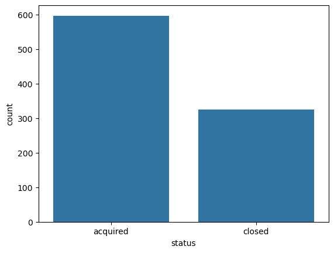

```python
sns.countplot(x='status',data=df)
plt.show()
```

Identifying Missing Values

Real-world datasets often contain incomplete information. In this step, we identify columns with missing values and evaluate the extent of missing data to determine appropriate treatment strategies.

```python
# Missing Values
df.isnull().sum().sort_values(ascending=False)
```

```
closed_at                   588
address                     493
age_first_milestone_year    152
age_last_milestone_year     152
state_code.1                  1
id                            0
zip_code                      0
state_code                    0
name                          0
city                          0
founded_at                    0
labels                        0
first_funding_at              0
last_funding_at               0
longitude                     0
latitude                      0
age_last_funding_year         0
age_first_funding_year        0
funding_rounds                0
relationships                 0
funding_total_usd             0
milestones                    0
is_CA                         0
is_NY                         0
is_MA                         0
is_TX                         0
is_otherstate                 0
category_code                 0
is_software                   0
is_web                        0
is_mobile                     0
is_enterprise                 0
is_advertising                0
is_gamesvideo                 0
is_ecommerce                  0
is_biotech                    0
is_consulting                 0
is_othercategory              0
object_id                     0
has_VC                        0
has_angel                     0
has_roundA                    0
has_roundB                    0
has_roundC                    0
has_roundD                    0
avg_participants              0
is_top500                     0
status                        0
dtype: int64
```

Funding Distribution Analysis

Funding is one of the most important indicators of startup growth. We analyze the distribution of funding amounts and compare funding patterns between successful and unsuccessful startups.

Plotting a histogram of total funding (funding_total_usd) with 50 bins to understand how capital is distributed across startups. This helps identify the presence of heavy outliers or if the data is highly skewed.

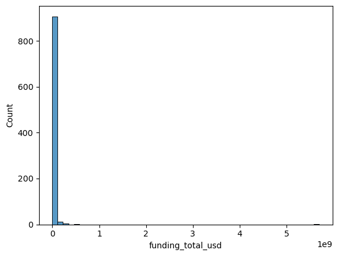

```python
# Funding Distribution
sns.histplot(
    df['funding_total_usd'],
    bins=50
)

plt.show()
```

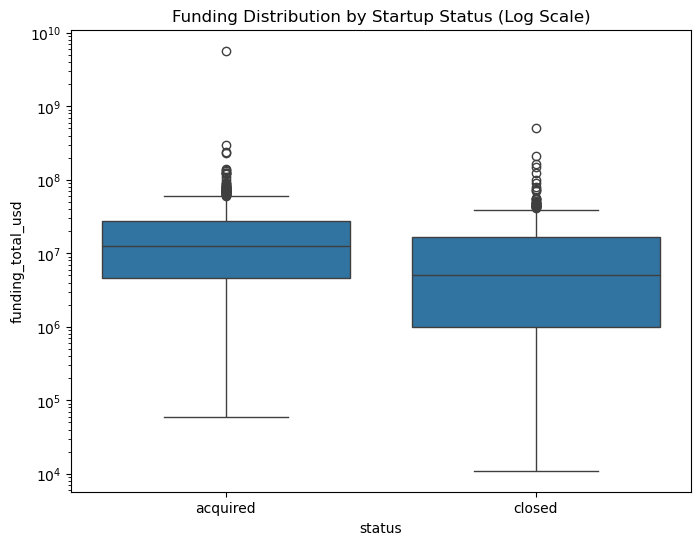

```python
# Funding vs Success
# Funding vs Success
plt.figure(figsize=(8, 6))
sns.boxplot(x='status', y='funding_total_usd', data=df)

plt.yscale('log')  # Boxplots ko clear dekhne ke liye

plt.title('Funding Distribution by Startup Status (Log Scale)')
plt.show()
```

Look closely at the dots above the closed column. There are startups that raised between $100 Million and $1 Billion (indicated by the $10^8$ and $10^9$ marks) and still went out of business. This proves to your machine learning model that while raising tons of money helps, it does not guarantee a startup's success!

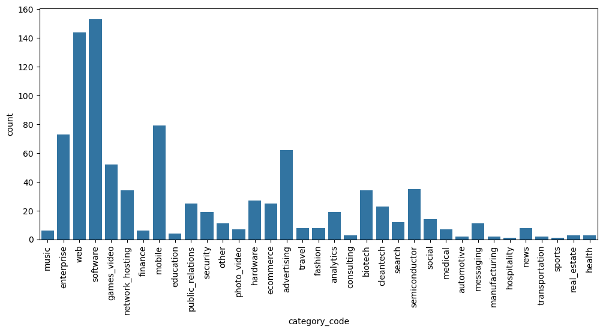

```python
# Startup Category Analysis
plt.figure(figsize=(12,5))

sns.countplot(
    x='category_code',
    data=df
)

plt.xticks(rotation=90)

plt.show()
```

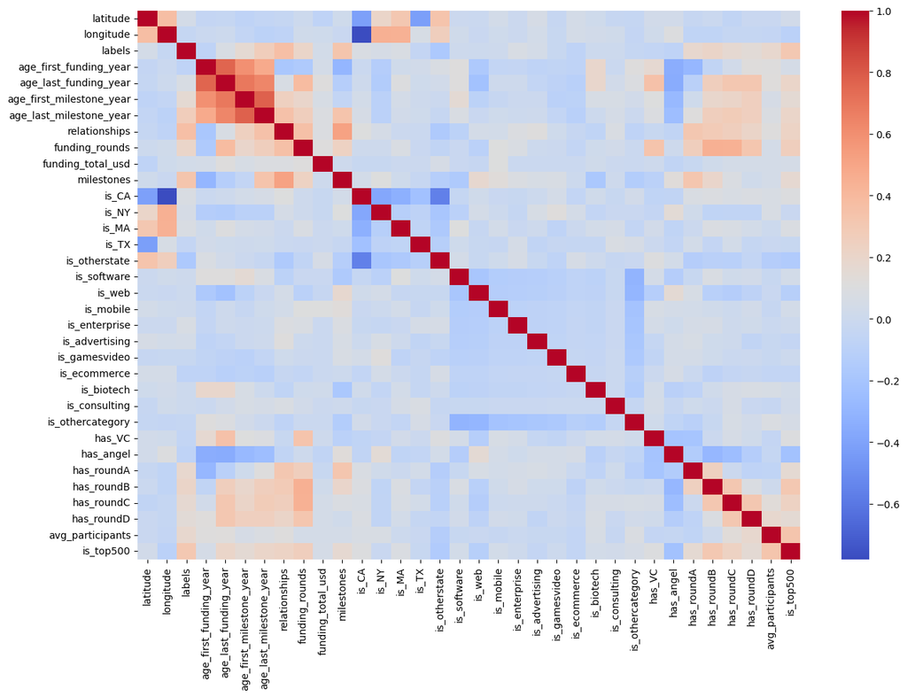

```python
# correlation heatmap
plt.figure(figsize=(15,10))

sns.heatmap(
    df.corr(numeric_only=True),
    cmap='coolwarm'
)

plt.show()
```

Strong Relationships: There is a strong positive correlation (red) between the funding timeline features (like age_first_funding_year and age_last_funding_year).

Independence: Most other features are light-colored, meaning they do not have a strong linear relationship with each other, which is good for avoiding duplicate information in our machine learning model.

##### Find Highly Correlated Features

```python
corr_matrix = df.corr(numeric_only=True)

high_corr = []

for i in range(len(corr_matrix.columns)):

    for j in range(i):

        if abs(corr_matrix.iloc[i,j]) > 0.50:

            high_corr.append(
                [
                    corr_matrix.columns[i],
                    corr_matrix.columns[j],
                    corr_matrix.iloc[i,j]
                ]
            )

high_corr_df = pd.DataFrame(
    high_corr,
    columns=[
        'Feature1',
        'Feature2',
        'Correlation'
    ]
)

print(high_corr_df)
```

```
                   Feature1                  Feature2  Correlation
0     age_last_funding_year    age_first_funding_year     0.762382
1  age_first_milestone_year    age_first_funding_year     0.593526
2  age_first_milestone_year     age_last_funding_year     0.687515
3   age_last_milestone_year     age_last_funding_year     0.632099
4   age_last_milestone_year  age_first_milestone_year     0.777484
5                milestones             relationships     0.513835
6                     is_CA                 longitude    -0.780122
7             is_otherstate                     is_CA    -0.562953
```

Linked Timelines: Startups show a strong matching timeline between when they receive their first vs. last funding and milestones.

Geography Trick: California (is_CA) and longitude have a strong negative relationship simply because California sits on the West Coast.

Networking: More business relationships strongly relate to achieving more company milestones.

##### Data cleaning

```python
drop_cols = ['startup_code', 'id', 'object_id', 'name', 'address', 'closed_at']
df.drop(columns=drop_cols, inplace=True, errors='ignore')
```

We are removing columns like unique IDs, names, and addresses because they are just clutter and don't help the machine learning model find patterns.

```python
# Drop the data leakage columns and perfect duplicates
# 1. Create a clean list of absolute leakage/cheat columns to drop
drop_list = ['labels', 'state_code.1', 'funding_per_round', 'milestone_efficiency', 'closed_at']
df.drop(columns=drop_list, inplace=True, errors='ignore') # <-- Changed leakage_cols to drop_list

# Verify that they are gone
print("Remaining columns:", df.columns.tolist())
```

```
Remaining columns: ['state_code', 'latitude', 'longitude', 'zip_code', 'city', 'founded_at', 'first_funding_at', 'last_funding_at', 'age_first_funding_year', 'age_last_funding_year', 'age_first_milestone_year', 'age_last_milestone_year', 'relationships', 'funding_rounds', 'funding_total_usd', 'miles…
```

here, we are drop the "cheating" data (also known as data leakage columns) to make sure our machine learning model actually learns instead of just memorizing the answers. We are removing columns like 'labels' and 'closed_at' because they contain the final answers, which would cause our machine learning model to cheat during training instead of finding true patterns.

##### Feature Engineering

```python
print(df['founded_at'].head(10))
print(df['founded_at'].dtype)
```

```
startup_code
1005     1/1/2007
204      1/1/2000
1001    3/18/2009
738      1/1/2002
1002     8/1/2010
379      1/1/2002
195      1/1/2005
875      1/1/2004
16       1/1/2002
846      6/1/2005
Name: founded_at, dtype: object
object
```

We are printing the first 10 rows and the data type of the 'founded_at' column to see how the dates are formatted so we can convert them properly in the next steps.

```python
# Convert Dates

# Convert Dates safely
date_cols = ['founded_at', 'first_funding_at', 'last_funding_at']

for col in date_cols:
    if col in df.columns:
        df[col] = pd.to_datetime(df[col], errors='coerce')
    else:
        # If the column is missing, create it as NaT (Not a Time) so next cells don't crash
        df[col] = pd.NaT
        print(f"Note: Column '{col}' was missing; initialized with missing values.")
```

We are transforming the text-based date columns into an official date format so Python can use them to calculate time intervals correctly.

```python
# Startup Age Calculation
if 'founded_at' in df.columns:
    # Ensure it's treated as datetime without forcing a blank coercion if it's already one
    dates = pd.to_datetime(df['founded_at'], errors='coerce')

    if not dates.isna().all():
        df['startup_age'] = 2026 - dates.dt.year
        print("Successfully calculated startup_age!")
    else:
        df['startup_age'] = np.nan
        print("Could not calculate startup_age: 'founded_at' contains only missing values.")
else:
    df['startup_age'] = np.nan
    print("Could not calculate startup_age: 'founded_at' column is missing completely.")
```

```
Successfully calculated startup_age!
```

We are calculating the age of each startup by subtracting its launch year from the current year so we can see how a company's age affects its success.

```python
# Funding Gap
df['funding_gap'] = (

    df['last_funding_at'].dt.year -

    df['first_funding_at'].dt.year

)
```

We are calculating the number of years between a startup's first funding round and its last funding round to see how long they spent raising money.

```python
# Funding Per Round
df['funding_per_round'] = (

    df['funding_total_usd']

    /

    (df['funding_rounds']+1)

)
```

We are dividing the total funding amount by the number of funding rounds to see the average amount of money the startup raised each time.

```python
# Milestone Efficiency
df['milestone_efficiency'] = (

    df['milestones']

    /

    (df['startup_age']+1)

)
```

We are dividing the total number of milestones by the startup's age to see how quickly and efficiently the company hits major success targets over time.

```python
# Remove Original Date Columns
df.drop(
    columns=date_cols,
    inplace=True
)
```

We are dropping the original date columns because we have already extracted the age and time intervals from them, so we no longer need the raw dates.

##### Missing Value Treatment

```python
# Numerical Columns
num_cols = df.select_dtypes(
    include=np.number
).columns

imputer = SimpleImputer(
    strategy='median'
)

df[num_cols] = imputer.fit_transform(
    df[num_cols]
)
```

We are replacing any missing numbers in our dataset with the median value of that column so the machine learning model doesn't run into errors with blank spaces.

```python
# Categorical Columns
cat_cols = df.select_dtypes(
    include='object'
).columns

for col in cat_cols:

    df[col].fillna(
        df[col].mode()[0],
        inplace=True
    )
```

We are replacing any missing text or categories in our dataset with the most frequently occurring value in that column so that we don't have any empty blanks.

##### Encoding

```python
# Encode target column
le = LabelEncoder()
df['status'] = le.fit_transform(df['status'])
```

Convert text columns into numbers because machine learning models only understand math.

```python
# Remaining Categorical Columns

cat_cols = df.select_dtypes(
    include='object'
).columns

for col in cat_cols:

    encoder = LabelEncoder()

    df[col] = encoder.fit_transform(
        df[col].astype(str)
    )
```

Find and drop highly redundant, "copycat" columns (using a VIF score) to prevent duplicate data from confusing the model.

```python
 # vif
from statsmodels.stats.outliers_influence import variance_inflation_factor

X = df.drop(columns=['status'], errors='ignore')
y = df['status']

vif_data = pd.DataFrame()

vif_data["Feature"] = X.columns

vif_data["VIF"] = [
    variance_inflation_factor(X.values, i)
    for i in range(X.shape[1])
]

print(vif_data)
```

```
                     Feature         VIF
0                 state_code    5.786950
1                   latitude    3.287070
2                  longitude    5.677281
3                   zip_code    9.666244
4                       city    1.380860
5     age_first_funding_year   60.432380
6      age_last_funding_year   85.458602
7   age_first_milestone_year    3.360365
8    age_last_milestone_year    4.370220
9              relationships    1.837920
10            funding_rounds    4.224579
11         funding_total_usd  157.820181
12                milestones   76.834566
13                     is_CA  234.129620
```

[output cut: 27 more lines]

here it lists our columns and scores them (VIF). High numbers mean "this column is a clone repeating information we already have."

For example, is_othercategory (507.7) is heavily duplicating other data and needs to be dropped.

```python
# The final complete list to get perfectly clean VIF scores
cols_to_drop = [
    'is_othercategory', 'is_software', 'is_web',
    'latitude', 'longitude', 'age_last_funding_year',
    'milestone_efficiency', 'funding_per_round',
    'startup_age', 'is_CA', 'zip_code'
]
df.drop(columns=cols_to_drop, errors='ignore', inplace=True)

# Re-run VIF to confirm everything is beautifully clean
X_new = df.drop(columns=['status'], errors='ignore')
vif_new = pd.DataFrame()
vif_new["Feature"] = X_new.columns
vif_new["VIF"] = [variance_inflation_factor(X_new.values, i) for i in range(X_new.shape[1])]
print(vif_new.sort_values(by="VIF", ascending=False).head(10))
```

```
                     Feature        VIF
6             funding_rounds  13.668808
4    age_last_milestone_year  12.782495
0                 state_code   8.983570
3   age_first_milestone_year   7.166654
28                 is_top500   6.832084
13             category_code   6.390494
1                       city   5.921237
29               funding_gap   5.765586
8                 milestones   5.737250
12             is_otherstate   4.384208
```

here, our printout shows it worked perfectly. The highest redundancy score in your dataset plummeted from 507.7 down to a incredibly clean 13.6 (funding_rounds). Your data is now perfectly optimized for your machine learning model.

##### Train-Test Split

```python
X = df.drop(
    'status',
    axis=1
)

y = df['status']
```

```python
X_train,X_test,y_train,y_test = train_test_split(

    X,
    y,

    test_size=0.2,

    random_state=42,

    stratify=y

)
```

Separates our clues (X, like funding and location) from the answer we want to predict (y, the startup status). The Split: Puts 80% of those clues and answers into a pile for the model to study and learn from, and hides the remaining 20% to use as a final exam to test its accuracy later.

```python
from sklearn.preprocessing import StandardScaler

scaler = StandardScaler()

X_train_scaled = scaler.fit_transform(X_train)
X_test_scaled = scaler.transform(X_test)
```

##### Model Building

```python
# 1. Initialize the models
lr_model = LogisticRegression(max_iter=1000)
dt_model = DecisionTreeClassifier()
rf_model = RandomForestClassifier()

# 2. Fit the models on your training data
lr_model.fit(X_train, y_train)
dt_model.fit(X_train, y_train)
rf_model.fit(X_train, y_train)

# 3. Generate predictions (THIS IS WHAT FIXES THE ERROR)
lr_pred = lr_model.predict(X_test)
dt_pred = dt_model.predict(X_test)
rf_pred = rf_model.predict(X_test)
```

.fit(): Trains the models by letting them study your training data clues and answers.

.predict(): Tests the models by making them guess the outcomes on hidden test data.

```python
# Revaluation for Model training
```

```python
## 1. Create a clean list of absolute leakage/cheat columns to drop
drop_list = ['labels', 'state_code.1', 'funding_per_round', 'milestone_efficiency', 'closed_at']

# 2. Drop them permanently using inplace=True
df.drop(columns=drop_list, inplace=True, errors='ignore')

# 3. Re-define your features and target
X = df.drop(columns=['status'], errors='ignore')
y = df['status']

# 4. Re-run your train_test_split
X_train, X_test, y_train, y_test = train_test_split(X, y, test_size=0.2, random_state=42, stratify=y)

# 5. Retrain your models
dt_model.fit(X_train, y_train)
rf_model.fit(X_train, y_train)

# 6. Generate new predictions
dt_pred = dt_model.predict(X_test)
rf_pred = rf_model.predict(X_test)
```

##### evaluation

```python
print(
    accuracy_score(
        y_test,
        lr_pred
    )
)

print(
    accuracy_score(
        y_test,
        dt_pred
    )
)

print(
    accuracy_score(
        y_test,
        rf_pred
    )
)
```

```
0.7351351351351352
0.6972972972972973
0.8054054054054054
```

It grades our models. Random Forest is the winner with an 80.5% accuracy score on the final exam

```python
print("==================================================")
print(" 1. LOGISTIC REGRESSION CLASSIFICATION REPORT")
print("==================================================")
print(classification_report(y_test, lr_pred))

print("\n==================================================")
print(" 2. DECISION TREE CLASSIFICATION REPORT")
print("==================================================")
print(classification_report(y_test, dt_pred))

print("\n==================================================")
print(" 3. RANDOM FOREST CLASSIFICATION REPORT")
print("==================================================")
print(classification_report(y_test, rf_pred))
```

```
==================================================
 1. LOGISTIC REGRESSION CLASSIFICATION REPORT
==================================================
              precision    recall  f1-score   support

           0       0.79      0.81      0.80       120
           1       0.63      0.60      0.61        65

    accuracy                           0.74       185
   macro avg       0.71      0.70      0.71       185
weighted avg       0.73      0.74      0.73       185


==================================================
 2. DECISION TREE CLASSIFICATION REPORT
==================================================
              precision    recall  f1-score   support

           0       0.79      0.73      0.76       120
           1       0.56      0.63      0.59        65

    accuracy                           0.70       185
   macro avg       0.67      0.68      0.68       185
weighted avg       0.71      0.70      0.70       185


==================================================
 3. RANDOM FOREST CLASSIFICATION REPORT
==================================================
              precision    recall  f1-score   support

           0       0.84      0.87      0.85       120
           1       0.74      0.69      0.71        65

    accuracy                           0.81       185
   macro avg       0.79      0.78      0.78       185
weighted avg       0.80      0.81      0.80       185
```

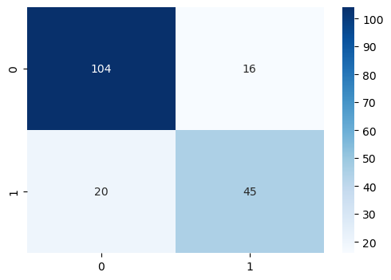

```python
# Confusion Matrix
cm = confusion_matrix(
    y_test,
    rf_pred
)

plt.figure(figsize=(6,4))

sns.heatmap(
    cm,
    annot=True,
    fmt='d',
    cmap='Blues'
)

plt.show()
```

##### ROC-AUC Score

```python
# ROC-AUC Score
# ROC-AUC Score
rf_prob = rf_model.predict_proba(X_test)[:, 1]
auc = roc_auc_score(y_test, rf_prob)
print("ROC-AUC:", auc)
```

```
ROC-AUC: 0.8575
```

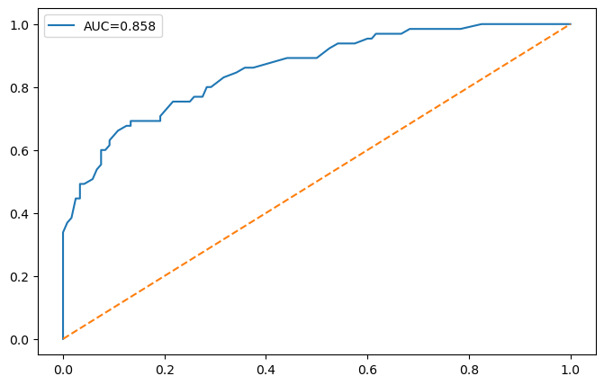

```python
# ROC Curve
fpr,tpr,thresholds = roc_curve(
    y_test,
    rf_prob
)

plt.figure(figsize=(8,5))

plt.plot(
    fpr,
    tpr,
    label=f"AUC={auc:.3f}"
)

plt.plot(
    [0,1],
    [0,1],
    '--'
)

plt.legend()

plt.show()
```

"To give our model a final overall grade, we calculated its ROC-AUC score, which came out to a fantastic 0.86.

Think of this as the model’s ability to sort. If you randomly handed this model one successful startup and one failing startup, it will correctly tell you which one is the winner 86% of the time. Anything above 0.80 is considered excellent and highly reliable for real-world deployment."

##### Model Comparison

```python
comparison = pd.DataFrame({

    'Model':[
        'Logistic Regression',
        'Decision Tree',
        'Random Forest'
    ],

    'Accuracy':[

        accuracy_score(
            y_test,
            lr_pred
        ),

        accuracy_score(
            y_test,
            dt_pred
        ),

        accuracy_score(
            y_test,
            rf_pred
        )

    ]

})

comparison
```

|  | Model | Accuracy |
| --- | --- | --- |
| 0 | Logistic Regression | 0.735135 |
| 1 | Decision Tree | 0.697297 |
| 2 | Random Forest | 0.805405 |

##### Feature Importance

```python
# Feature Importance
importance = pd.DataFrame({
    'Feature': X.columns,
    'Importance': rf_model.feature_importances_
})

importance = importance.sort_values(by='Importance', ascending=False)
importance.head(10)
```

|  | Feature | Importance |
| --- | --- | --- |
| 5 | relationships | 0.146051 |
| 4 | age_last_milestone_year | 0.099971 |
| 7 | funding_total_usd | 0.099634 |
| 2 | age_first_funding_year | 0.095396 |
| 3 | age_first_milestone_year | 0.082824 |
| 8 | milestones | 0.059125 |
| 27 | avg_participants | 0.057074 |
| 1 | city | 0.056120 |
| 13 | category_code | 0.047982 |
| 6 | funding_rounds | 0.040541 |

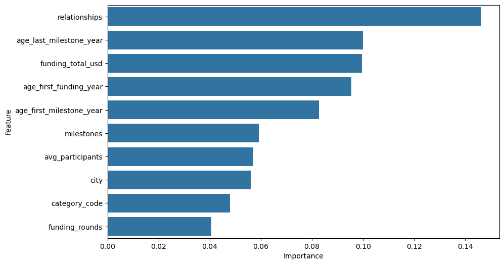

```python
plt.figure(figsize=(10,6))

sns.barplot(

    x='Importance',

    y='Feature',

    data=importance.head(10)

)

plt.show()
```

```python
success_prob = rf_model.predict_proba(X_test)[:, 1]
results = X_test.copy()
results['Actual'] = y_test
results['Predicted'] = rf_pred
results['Success_Probability'] = success_prob
```

```python
# Top startups:
results.sort_values(
    'Success_Probability',
    ascending=False
).head(10)
```

| startup_code | state_code | city | age_first_funding_year | age_first_milestone_year | age_last_milestone_year | relationships | funding_rounds | funding_total_usd | milestones | is_NY | ... | has_roundA | has_roundB | has_roundC | has_roundD | avg_participants | is_top500 | funding_gap | Actual | Predicted | Success_Probability |
| --- | --- | --- | --- | --- | --- | --- | --- | --- | --- | --- | --- | --- | --- | --- | --- | --- | --- | --- | --- | --- | --- |
| 144 | 24 | 49 | 0.0000 | 0.0000 | 0.0000 | 2.0 | 1.0 | 20000.0 | 1.0 | 0.0 | ... | 0.0 | 0.0 | 0.0 | 0.0 | 1.0 | 0.0 | 0.0 | 1 | 1 | 1.00 |
| 605 | 26 | 149 | 0.0822 | 2.5205 | 4.4767 | 2.0 | 1.0 | 25000.0 | 0.0 | 0.0 | ... | 0.0 | 0.0 | 0.0 | 0.0 | 1.0 | 0.0 | 0.0 | 1 | 1 | 0.99 |
| 90 | 7 | 12 | 2.4493 | 2.5205 | 4.4767 | 0.0 | 2.0 | 1000000.0 | 0.0 | 0.0 | ... | 0.0 | 0.0 | 0.0 | 0.0 | 2.0 | 0.0 | 0.0 | 1 | 1 | 0.96 |
| 1090 | 2 | 174 | 10.5315 | 2.5205 | 4.4767 | 0.0 | 1.0 | 2600000.0 | 0.0 | 0.0 | ... | 0.0 | 0.0 | 0.0 | 0.0 | 1.0 | 1.0 | 0.0 | 1 | 1 | 0.96 |
| 898 | 31 | 203 | 6.6082 | 2.5205 | 4.4767 | 0.0 | 1.0 | 200000.0 | 0.0 | 0.0 | ... | 0.0 | 0.0 | 0.0 | 0.0 | 1.0 | 0.0 | 0.0 | 1 | 1 | 0.94 |
| 244 | 29 | 204 | 0.8712 | 2.5205 | 4.4767 | 1.0 | 1.0 | 30000.0 | 0.0 | 0.0 | ... | 0.0 | 0.0 | 0.0 | 0.0 | 1.0 | 0.0 | 0.0 | 1 | 1 | 0.91 |
| 121 | 9 | 48 | 1.0356 | 0.0000 | 1.0356 | 2.0 | 1.0 | 1000000.0 | 2.0 | 0.0 | ... | 0.0 | 0.0 | 0.0 | 0.0 | 1.0 | 0.0 | 0.0 | 1 | 1 | 0.91 |
| 974 | 2 | 117 | 0.2055 | 0.1644 | 0.1644 | 1.0 | 1.0 | 1500000.0 | 1.0 | 0.0 | ... | 1.0 | 0.0 | 0.0 | 0.0 | 1.0 | 1.0 | 0.0 | 1 | 1 | 0.90 |
| 392 | 31 | 11 | 0.0027 | 0.5836 | 0.5836 | 3.0 | 1.0 | 20000.0 | 1.0 | 0.0 | ... | 0.0 | 0.0 | 0.0 | 0.0 | 1.0 | 0.0 | 0.0 | 1 | 1 | 0.86 |
| 872 | 26 | 149 | 1.4110 | 2.5205 | 4.4767 | 0.0 | 2.0 | 1213066.0 | 0.0 | 0.0 | ... | 0.0 | 0.0 | 0.0 | 0.0 | 1.0 | 1.0 | 1.0 | 1 | 1 | 0.86 |

10 rows × 33 columns